# 02 · Test Cleaning Strategies

Use this notebook to prototype different `DataCleanerConfig` combinations before wiring them into automated jobs. Each run reuses the production cleaner so results mirror what would happen in `scripts/data-cleaner.py`.

## Notebook goals

- Quickly compare multiple cleaning strategies without editing production code
- Capture row-retention and missing-value metrics per strategy
- Surface trade-offs (strict vs. relaxed) for stakeholders
- Provide reusable helper functions for future experiments

```python
from __future__ import annotations

from pathlib import Path
import importlib.util
import sys
from dataclasses import dataclass

import dask.dataframe as dd
import matplotlib.pyplot as plt
from IPython.display import display
import pandas as pd
import seaborn as sns

plt.style.use("seaborn-v0_8")
sns.set_theme(style="whitegrid")
pd.set_option("display.max_columns", 50)

PROJECT_ROOT = Path.cwd().resolve().parents[1]
DATA_PATH = PROJECT_ROOT / "data" / "national_water_plan.csv"
SCRIPTS_DIR = PROJECT_ROOT / "scripts"


def load_module(module_name: str, file_path: Path):
    if module_name in sys.modules:
        return sys.modules[module_name]
    spec = importlib.util.spec_from_file_location(module_name, file_path)
    module = importlib.util.module_from_spec(spec)
    sys.modules[module_name] = module
    spec.loader.exec_module(module)
    return module


data_loader = load_module("project_data_loader", SCRIPTS_DIR / "data-loader.py")
DataLoader = data_loader.DataLoader
DataConfig = data_loader.DataConfig

data_cleaner = load_module("project_data_cleaner", SCRIPTS_DIR / "data-cleaner.py")
DataCleanerConfig = data_cleaner.DataCleanerConfig
WaterDataCleaner = data_cleaner.WaterDataCleaner
```

```
Pydantic enhancements module not available. Using basic features only.
```

[output not shown]

[output not shown]

## 1. Load data & build a working sample

The sample keeps experiments fast while still flowing through the exact same cleaning methods.

```python
data_config = DataConfig(filepath=str(DATA_PATH))
loader = DataLoader(data_config)
raw_ddf, exploration_report = loader.load_and_explore_data()

SAMPLE_ROWS = 20_000
sample_pdf = raw_ddf.head(SAMPLE_ROWS, compute=True)
print(f"Exploration rows: {exploration_report.metadata.rows:,}")
print(f"Sample size: {len(sample_pdf):,}")
```

```
Duplicate check failed: _sum() got an unexpected keyword argument 'skipna'
```

```
Duplicate check failed in statistics: _sum() got an unexpected keyword argument 'skipna'
```

```
Duplicate check failed: _sum() got an unexpected keyword argument 'skipna'
```

```
Duplicate check skipped (not supported for this operation)
```

```
High missing data percentage: 8.10%
```

```
Exploration rows: 14,187
Sample size: 14,187
```

```python
CleaningReport = data_cleaner.CleaningReport

@dataclass
class StrategyResult:
    name: str
    description: str
    config: DataCleanerConfig
    report: CleaningReport
    cleaned_ddf: "dd.DataFrame"


def run_cleaning_strategy(name: str, description: str, overrides: dict) -> StrategyResult:
    base_kwargs = dict(
        strict_mode=True,
        remove_duplicates=True,
        remove_outliers=True,
        remove_invalid_spill_years=True,
        remove_invalid_text_values=True,
        create_backup=False,
        save_cleaning_report=False,
        output_directory="/tmp",
    )
    base_kwargs.update(overrides)
    config = DataCleanerConfig(**base_kwargs)
    cleaner = WaterDataCleaner(config)
    cleaned_ddf, report = cleaner.clean_data(sample_pdf.copy(), output_dir=None)
    return StrategyResult(name, description, config, report, cleaned_ddf)
```

## 2. Define strategy grid

Tweak just a handful of parameters per strategy so we can reason about the outcome of each change.

```python
strategies = [
    {
        "name": "strict_default",
        "description": "Baseline configuration with strict column requirements and duplicate removal.",
        "overrides": {},
    },
    {
        "name": "relaxed_text",
        "description": "Allow rows that miss optional text fields while keeping numeric validation strict.",
        "overrides": {
            "remove_invalid_text_values": False,
            "missing_value_threshold": 0.4,
        },
    },
    {
        "name": "spill_imputation",
        "description": "Fill missing spill values with zeroes and keep rows even if only two years are available.",
        "overrides": {
            "fill_missing_values": True,
            "fill_value": 0,
            "remove_invalid_spill_years": False,
            "min_valid_spill_years": 2,
        },
    },
    {
        "name": "aggressive_outliers",
        "description": "Tighten outlier filtering to 2σ and demand four valid spill years.",
        "overrides": {
            "outlier_std_threshold": 2.0,
            "min_valid_spill_years": 4,
        },
    },
]

strategies
```

```
[{'name': 'strict_default',
  'description': 'Baseline configuration with strict column requirements and duplicate removal.',
  'overrides': {}},
 {'name': 'relaxed_text',
  'description': 'Allow rows that miss optional text fields while keeping numeric validation strict.',
  'overrides': {'remove_invalid_text_values': False,
   'missing_value_threshold': 0.4}},
 {'name': 'spill_imputation',
  'description': 'Fill missing spill values with zeroes and keep rows even if only two years are available.',
  'overrides': {'fill_missing_values': True,
   'fill_value': 0,
   'remove_invalid_spill_years': False,
   'min_valid_spill_years': 2}},
 {'name': 'aggressive_outliers',
  'description': 'Tighten outlier filtering to 2σ and demand four valid spill years.',
  'overrides': {'outlier_std_threshold': 2.0, 'min_valid_spill_years': 4}}]
```

```python
results: list[StrategyResult] = []
for strat in strategies:
    result = run_cleaning_strategy(strat["name"], strat["description"], strat["overrides"])
    results.append(result)
    print(f"✓ {strat['name']} completed — rows retained: {result.report.cleaned_shape[0]:,}")
```

```
2025-11-21 11:40:28,665 - project_data_cleaner - INFO - Starting data cleaning pipeline
```

```
2025-11-21 11:40:28,667 - project_data_cleaner - INFO - Converting Pandas DataFrame to Dask DataFrame
```

```
2025-11-21 11:40:28,695 - project_data_cleaner - INFO - Collecting initial statistics
```

```
2025-11-21 11:40:28,838 - project_data_cleaner - WARNING - Could not calculate initial duplicates
```

```
2025-11-21 11:40:28,843 - project_data_cleaner - INFO - Step 1: Validating columns
```

```
2025-11-21 11:40:28,844 - project_data_cleaner - INFO - Missing optional columns: ['Site Name', 'Permit Number']
```

```
2025-11-21 11:40:28,845 - project_data_cleaner - INFO - Step 2: Cleaning coordinates
```

```
2025-11-21 11:40:28,966 - project_data_cleaner - INFO - Step 3: Cleaning spill events
```

```
2025-11-21 11:40:28,968 - project_data_cleaner - INFO - Cleaning 3 spill event columns
```

```
2025-11-21 11:40:29,241 - project_data_cleaner - WARNING - Removing 233 outliers from Spill Events 2020
```

```
2025-11-21 11:40:29,599 - project_data_cleaner - WARNING - Removing 219 outliers from Spill Events 2021
```

```
2025-11-21 11:40:30,102 - project_data_cleaner - WARNING - Removing 238 outliers from Spill Events 2022
```

```
2025-11-21 11:40:30,443 - project_data_cleaner - WARNING - Removing 3253 rows with < 3 valid spill years
```

```
2025-11-21 11:40:30,447 - project_data_cleaner - INFO - Step 4: Cleaning text fields
```

```
2025-11-21 11:40:31,787 - project_data_cleaner - INFO - Step 5: Removing duplicates
```

```
2025-11-21 11:40:33,693 - project_data_cleaner - INFO - Step 6: Handling missing values
```

```
2025-11-21 11:40:34,919 - project_data_cleaner - WARNING - Removing 1990 rows exceeding missing value threshold
```

```
2025-11-21 11:40:34,924 - project_data_cleaner - INFO - Collecting final statistics
```

```
2025-11-21 11:40:38,214 - project_data_cleaner - INFO - Cleaning completed: 14187 -> 8944 rows (63.0% retained) in 9.55s
```

```
2025-11-21 11:40:38,220 - project_data_cleaner - INFO - Starting data cleaning pipeline
```

```
2025-11-21 11:40:38,221 - project_data_cleaner - INFO - Converting Pandas DataFrame to Dask DataFrame
```

```
2025-11-21 11:40:38,238 - project_data_cleaner - INFO - Collecting initial statistics
```

```
2025-11-21 11:40:38,326 - project_data_cleaner - WARNING - Could not calculate initial duplicates
```

```
2025-11-21 11:40:38,328 - project_data_cleaner - INFO - Step 1: Validating columns
```

```
2025-11-21 11:40:38,330 - project_data_cleaner - INFO - Missing optional columns: ['Site Name', 'Permit Number']
```

```
2025-11-21 11:40:38,330 - project_data_cleaner - INFO - Step 2: Cleaning coordinates
```

```
2025-11-21 11:40:38,414 - project_data_cleaner - INFO - Step 3: Cleaning spill events
```

```
2025-11-21 11:40:38,416 - project_data_cleaner - INFO - Cleaning 3 spill event columns
```

```
✓ strict_default completed — rows retained: 8,944
```

```
2025-11-21 11:40:38,548 - project_data_cleaner - WARNING - Removing 233 outliers from Spill Events 2020
```

```
2025-11-21 11:40:38,740 - project_data_cleaner - WARNING - Removing 219 outliers from Spill Events 2021
```

```
2025-11-21 11:40:38,950 - project_data_cleaner - WARNING - Removing 238 outliers from Spill Events 2022
```

```
2025-11-21 11:40:39,115 - project_data_cleaner - WARNING - Removing 3253 rows with < 3 valid spill years
```

```
2025-11-21 11:40:39,116 - project_data_cleaner - INFO - Step 4: Cleaning text fields
```

```
2025-11-21 11:40:39,119 - project_data_cleaner - INFO - Step 5: Removing duplicates
```

```
2025-11-21 11:40:40,015 - project_data_cleaner - INFO - Step 6: Handling missing values
```

```
2025-11-21 11:40:40,741 - project_data_cleaner - INFO - Collecting final statistics
```

```
2025-11-21 11:40:42,577 - project_data_cleaner - INFO - Cleaning completed: 14187 -> 10934 rows (77.1% retained) in 4.36s
```

```
2025-11-21 11:40:42,585 - project_data_cleaner - INFO - Starting data cleaning pipeline
```

```
2025-11-21 11:40:42,585 - project_data_cleaner - INFO - Converting Pandas DataFrame to Dask DataFrame
```

```
2025-11-21 11:40:42,600 - project_data_cleaner - INFO - Collecting initial statistics
```

```
2025-11-21 11:40:42,671 - project_data_cleaner - WARNING - Could not calculate initial duplicates
```

```
2025-11-21 11:40:42,674 - project_data_cleaner - INFO - Step 1: Validating columns
```

```
2025-11-21 11:40:42,675 - project_data_cleaner - INFO - Missing optional columns: ['Site Name', 'Permit Number']
```

```
2025-11-21 11:40:42,676 - project_data_cleaner - INFO - Step 2: Cleaning coordinates
```

```
2025-11-21 11:40:42,740 - project_data_cleaner - INFO - Step 3: Cleaning spill events
```

```
2025-11-21 11:40:42,741 - project_data_cleaner - INFO - Cleaning 3 spill event columns
```

```
✓ relaxed_text completed — rows retained: 10,934
```

```
2025-11-21 11:40:42,852 - project_data_cleaner - WARNING - Removing 233 outliers from Spill Events 2020
```

```
2025-11-21 11:40:43,008 - project_data_cleaner - WARNING - Removing 219 outliers from Spill Events 2021
```

```
2025-11-21 11:40:43,219 - project_data_cleaner - WARNING - Removing 238 outliers from Spill Events 2022
```

```
2025-11-21 11:40:43,220 - project_data_cleaner - INFO - Step 4: Cleaning text fields
```

```
2025-11-21 11:40:43,539 - project_data_cleaner - INFO - Step 5: Removing duplicates
```

```
2025-11-21 11:40:44,418 - project_data_cleaner - INFO - Step 6: Handling missing values
```

```
2025-11-21 11:40:44,420 - project_data_cleaner - INFO - Filled missing values with: 0
```

```
2025-11-21 11:40:44,421 - project_data_cleaner - INFO - Collecting final statistics
```

```
2025-11-21 11:40:46,311 - project_data_cleaner - INFO - Cleaning completed: 14187 -> 14187 rows (100.0% retained) in 3.73s
```

```
2025-11-21 11:40:46,316 - project_data_cleaner - INFO - Starting data cleaning pipeline
```

```
2025-11-21 11:40:46,317 - project_data_cleaner - INFO - Converting Pandas DataFrame to Dask DataFrame
```

```
2025-11-21 11:40:46,333 - project_data_cleaner - INFO - Collecting initial statistics
```

```
2025-11-21 11:40:46,407 - project_data_cleaner - WARNING - Could not calculate initial duplicates
```

```
2025-11-21 11:40:46,408 - project_data_cleaner - INFO - Step 1: Validating columns
```

```
2025-11-21 11:40:46,409 - project_data_cleaner - INFO - Missing optional columns: ['Site Name', 'Permit Number']
```

```
2025-11-21 11:40:46,410 - project_data_cleaner - INFO - Step 2: Cleaning coordinates
```

```
2025-11-21 11:40:46,475 - project_data_cleaner - INFO - Step 3: Cleaning spill events
```

```
2025-11-21 11:40:46,476 - project_data_cleaner - INFO - Cleaning 3 spill event columns
```

```
✓ spill_imputation completed — rows retained: 14,187
```

```
2025-11-21 11:40:46,583 - project_data_cleaner - WARNING - Removing 577 outliers from Spill Events 2020
```

```
2025-11-21 11:40:46,741 - project_data_cleaner - WARNING - Removing 583 outliers from Spill Events 2021
```

```
2025-11-21 11:40:46,954 - project_data_cleaner - WARNING - Removing 635 outliers from Spill Events 2022
```

```
2025-11-21 11:40:47,124 - project_data_cleaner - WARNING - Removing 14187 rows with < 4 valid spill years
```

```
2025-11-21 11:40:47,125 - project_data_cleaner - INFO - Step 4: Cleaning text fields
```

```
2025-11-21 11:40:47,611 - project_data_cleaner - INFO - Step 5: Removing duplicates
```

```
2025-11-21 11:40:48,896 - project_data_cleaner - INFO - Step 6: Handling missing values
```

```
2025-11-21 11:40:49,546 - project_data_cleaner - INFO - Collecting final statistics
```

```
2025-11-21 11:40:51,690 - project_data_cleaner - INFO - Cleaning completed: 14187 -> 0 rows (0.0% retained) in 5.37s
```

```
✓ aggressive_outliers completed — rows retained: 0
```

## 3. Compare outcomes

Aggregate the metrics that matter most (row retention, missing %, duplicates removed) and visualize trade-offs.

```python
summary_records = []
for result in results:
    metrics = result.report.quality_metrics
    summary_records.append(
        {
            "strategy": result.name,
            "description": result.description,
            "rows_in": result.report.original_shape[0],
            "rows_out": result.report.cleaned_shape[0],
            "rows_retained_pct": metrics.get("rows_retained_percent"),
            "initial_missing_pct": metrics.get("initial_missing_percent"),
            "final_missing_pct": metrics.get("final_missing_percent"),
            "duplicates_removed": metrics.get("duplicate_reduction"),
        }
    )

summary_df = pd.DataFrame(summary_records)
summary_df
```

|  | strategy | description | rows_in | rows_out | rows_retained_pct | initial_missing_pct | final_missing_pct | duplicates_removed |
| --- | --- | --- | --- | --- | --- | --- | --- | --- |
| 0 | strict_default | Baseline configuration with strict column requ... | 14187 | 8944 | 63.043631 | 8.096367 | 5.173418 | 0 |
| 1 | relaxed_text | Allow rows that miss optional text fields whil... | 14187 | 10934 | 77.070558 | 8.096367 | 6.321181 | 0 |
| 2 | spill_imputation | Fill missing spill values with zeroes and keep... | 14187 | 14187 | 100.000000 | 8.096367 | 0.000000 | 0 |
| 3 | aggressive_outliers | Tighten outlier filtering to 2σ and demand fou... | 14187 | 0 | 0.000000 | 8.096367 | 0.000000 | 0 |

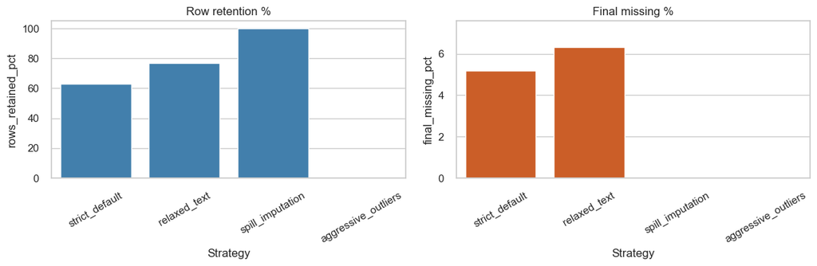

```python
fig, axes = plt.subplots(1, 2, figsize=(12, 4))
sns.barplot(data=summary_df, x="strategy", y="rows_retained_pct", ax=axes[0], color="#3182bd")
axes[0].set_title("Row retention %")
axes[0].set_ylim(0, 105)

sns.barplot(data=summary_df, x="strategy", y="final_missing_pct", ax=axes[1], color="#e6550d")
axes[1].set_title("Final missing %")
axes[1].set_ylim(0, summary_df["final_missing_pct"].max() * 1.2)

for ax in axes:
    ax.set_xlabel("Strategy")
    ax.tick_params(axis="x", rotation=30)

plt.tight_layout()
plt.show()
```

### Removal breakdown per strategy

Inspect which rules are driving the drop in rows to tune thresholds precisely.

```python
removal_records = []
for result in results:
    breakdown = result.report.removal_breakdown or {}
    for reason, count in breakdown.items():
        removal_records.append(
            {
                "strategy": result.name,
                "reason": reason,
                "rows_removed": count,
            }
        )

if removal_records:
    breakdown_df = (
        pd.DataFrame(removal_records)
        .pivot_table(index="reason", columns="strategy", values="rows_removed", fill_value=0)
        .reindex(columns=summary_df["strategy"], fill_value=0)
        .sort_index(ascending=False)
    )
else:
    breakdown_df = pd.DataFrame()

breakdown_df
```

| strategy reason | strict_default | relaxed_text | spill_imputation | aggressive_outliers |
| --- | --- | --- | --- | --- |
| insufficient_spill_years | 3253.0 | 3253.0 | 0 | 14187.0 |
| high_missing_values | 1990.0 | 0.0 | 0 | 0.0 |

### Peek at cleaned sample for a chosen strategy

Use this helper to inspect the head/tail of the cleaned Dask DataFrame (converted to pandas for convenience).

```python
def preview_strategy(strategy_name: str, n: int = 5):
    match = next((r for r in results if r.name == strategy_name), None)
    if match is None:
        raise ValueError(f"Strategy '{strategy_name}' not found. Choose from {[r.name for r in results]}")
    preview_df = match.cleaned_ddf.head(n, compute=True)
    display(preview_df)


preview_strategy("strict_default")
```

|  | ID | Water company | Site name | Longitude | Latitude | Receiving Environment | River Basin District | Management Catchment | Local Authority | Water Body | Bathing Water Discharge Flag | Shellfish Water Discharge Flag | Ecological High Priority Site Flag | Marine Protected Area Discharge Flag | Non-bathing Priority Site Flag | Spill Events 2020 | Spill Events 2021 | Spill Events 2022 | Sewage Reduction Plan Targets Met Flag | Spill Improvement Date Planned | Rainfall Improvement Target Delivery Flag | Improvements List | Predicted Annual Spill Frequence Post Scheme | Baseline | Baseline Less Than Target | Requires No Improvement | Meets 2025 Requirements | Meets 2030 Requirements | Meets 2035 Requirements | … |
| --- | --- | --- | --- | --- | --- | --- | --- | --- | --- | --- | --- | --- | --- | --- | --- | --- | --- | --- | --- | --- | --- | --- | --- | --- | --- | --- | --- | --- | --- | --- |
| 19 | AnW0021 | Anglian Water | ASHTON WATER RECYCLING CENTRE | -0.879539 | 52.132370 | Inland | Anglian | Upper and Bedford Ouse | West Northamptonshire | Tove (DS Greens Norton) | N | N | N | N | <NA> | 0.0 | 0.0 | 0.0 | Y | 2023.0 | <NA> | Improvements to be confirmed | 10.0 | 0.0 | Y | Y | 1.0 | 1.0 | 1.0 | … |
| 20 | AnW0022 | Anglian Water | ASHWELL WATER RECYCLING CENTRE | -0.171398 | 52.052929 | Inland | Anglian | Cam and Ely Ouse | North Hertfordshire | Rhee (US Wendy) | N | N | N | N | <NA> | 2.0 | 2.0 | 24.0 | Y | 2023.0 | <NA> | Improvements to be confirmed | 10.0 | 2.0 | Y | Y | 1.0 | 1.0 | 1.0 | … |
| 23 | AnW0025 | Anglian Water | ATTLEBOROUGH WRC | 0.989322 | 52.515652 | Inland | Anglian | Cam and Ely Ouse | Breckland | Thet (US Swangey Fen) | N | N | N | N | <NA> | 6.0 | 1.0 | 2.0 | Y | 2023.0 | <NA> | Storage. Other improvements to be confirmed | 10.0 | 6.0 | Y | Y | 1.0 | 1.0 | 1.0 | … |
| 24 | AnW0026 | Anglian Water | ATTLEBOROUGH NORWICH ROAD PS | 1.030924 | 52.524269 | Inland | Anglian | Cam and Ely Ouse | Breckland | Thet (US Swangey Fen) | N | N | N | N | <NA> | 3.0 | 1.0 | 3.0 | Y | 2023.0 | <NA> | Operational (e.g. blockages). Other improvemen... | 10.0 | 3.0 | Y | Y | 1.0 | 1.0 | 1.0 | … |
| 40 | AnW0044 | Anglian Water | BARNETBY - FERNERY LA TERMINAL PS | -0.408335 | 53.574852 | Inland | Humber | Louth Grimsby and Ancholme | North Lincolnshire | Kettleby Beck | N | N | N | N | <NA> | 1.0 | 27.0 | 11.0 | N | 2040.0 | <NA> | Operational (e.g. blockages). Other improvemen... | 10.0 | 1.0 | Y | Y | 1.0 | 1.0 | 1.0 | … |

## Takeaways

- Use the summary table to document how each config impacts retention vs. quality.
- Feed promising overrides back into `DataCleanerConfig` defaults or environment-specific settings.
- Commit strategy descriptions so future analysts understand *why* thresholds changed.